GUÍA DE ESTUDIO

# Procesamiento avanzado de imágenes

Una introducción desde cero: de qué es un píxel hasta filtros, bordes, frecuencia, morfología y detección de objetos. Con ejemplos reales sobre imágenes.

**Cómo leer esta guía.** Cada tema tiene: la **intuición** (en criollo), la **idea técnica** y, cuando aplica, un **ejemplo real**. Los recuadros amarillos son analogías; los verdes, cosas para probar; los azules, definiciones clave. No necesitás saber nada previo.

## Capítulo 1¿Qué es una imagen digital?

Una imagen digital es simplemente una **tabla de números**. La dividimos en una grilla de celdas llamadas **píxeles**, y a cada píxel le asignamos un número que representa su brillo.

[figure not shown]

En una imagen en **escala de grises**, cada píxel es un número entre **0 (negro)** y **255 (blanco)**. Ese rango 0–255 sale de usar **8 bits** por píxel (2⁸ = 256 valores); a eso se le llama **profundidad de bits**.

Una imagen a **color** usa tres tablas (canales) superpuestas: **R**ojo, **G** verde y **B** azul. Cada píxel tiene tres números, y su combinación da el color final.

**En criollo:** pensá una imagen como una planilla de Excel gigante donde cada celda pintada de un gris distinto. Procesar imágenes = hacerle cuentas a esa planilla.

**Términos clave.** **Píxel**: la celda mínima. **Resolución**: cuántos píxeles (ej. 570×686). **Canal**: cada tabla de color. **Profundidad**: cuántos valores puede tomar un píxel (8 bits → 0–255).

## Capítulo 2Histograma y transformaciones de intensidad viste esto en el TP

El **histograma** es un gráfico que cuenta **cuántos píxeles hay de cada nivel de gris**. Si una imagen es oscura, su histograma se amontona a la izquierda; si es clara, a la derecha; si tiene poco contraste, se apretuja en el medio.

Una **transformación de intensidad** cambia el valor de cada píxel según una función, sin mirar a sus vecinos. Ejemplos:

- **Negativo:** `s = 255 − r`. Invierte (útil para resaltar detalles oscuros).
- **Gamma / potencia:** `s = c·r^γ`. Aclara u oscurece de forma no lineal.
- **Logarítmica:** comprime rangos muy amplios (se usa para ver espectros de Fourier).
- **Estiramiento de contraste:** mapea el rango usado a todo 0–255.

### Ecualización de histograma

Es la estrella del tema: **redistribuye** los niveles de gris para usar todo el rango y **maximizar el contraste**. Se calcula la curva acumulada del histograma (CDF) y se la usa como función de mapeo.

nuevo_valor = round( 255 × CDF(intensidad) )

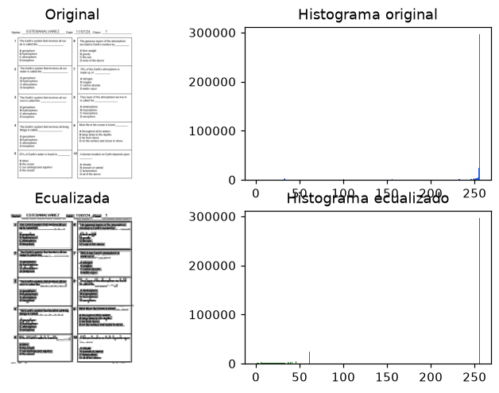

**En criollo:** ecualizar es "estirar" los grises para que ocupen todo el rango del negro al blanco. En tu TP hiciste la versión **local** (ventana por ventana) que revela detalles escondidos que la global no puede.

## Capítulo 3Filtrado espacial y convolución clave

Hasta acá cambiábamos cada píxel solo. Ahora entra el concepto más importante del área: mirar a cada píxel **junto con sus vecinos**. La herramienta es la **convolución** con un **kernel** (una matriz chica, por ejemplo 3×3).

La receta: se apoya el kernel sobre cada píxel, se **multiplica celda a celda** con el vecindario, se **suman** todos los productos, y ese número es el nuevo valor del píxel central. Después se corre el kernel un lugar y se repite por toda la imagen.

[figure not shown]

**Kernel (o máscara):** la matriz de pesos que define **qué hace** el filtro. Cambiando los números del kernel obtenés efectos totalmente distintos con el mismo mecanismo.

### Filtros de suavizado (pasa-bajos)

Promedian el vecindario → **borronean** la imagen y reducen el ruido. El **filtro de promedio** usa pesos iguales; el **gaussiano** da más peso al centro (más natural). Cuanto más grande el kernel, más borroso.

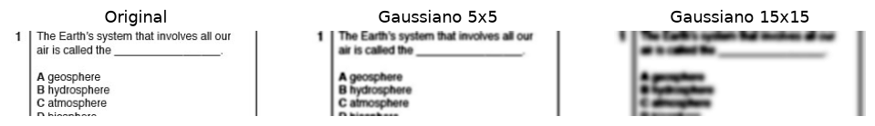

Suavizado gaussiano: a mayor tamaño de kernel, más difuminado.

### Filtro de mediana

Caso especial no lineal: reemplaza cada píxel por la **mediana** de su vecindario. Es el mejor para el ruido **"sal y pimienta"** (puntitos blancos y negros), porque elimina los valores extremos sin borronear tanto los bordes.

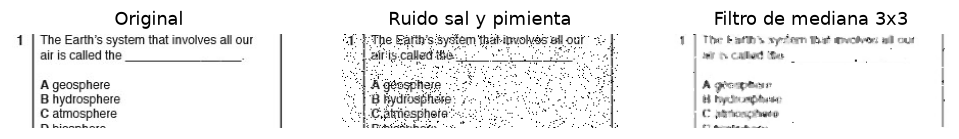

El filtro de mediana limpia el ruido sal y pimienta casi por completo.

**Para probar:** en OpenCV, `cv2.blur`, `cv2.GaussianBlur` y `cv2.medianBlur`. Cambiá el tamaño del kernel y mirá cómo cambia el resultado.

## Capítulo 4Realce y detección de bordes viste Sobel en el TP

Los **bordes** son los lugares donde el brillo **cambia bruscamente** (el contorno de un objeto). Detectarlos = medir ese cambio, que matemáticamente es la **derivada** (gradiente) de la imagen.

- **Filtros pasa-altos:** lo opuesto al suavizado; resaltan los cambios rápidos (bordes y detalles finos).
- **Sobel:** calcula el gradiente en X y en Y con dos kernels. Combinados, marcan todos los bordes. Lo usaste para detectar la línea de respuesta en cada celda.
- **Laplaciano:** usa la segunda derivada; sirve para **realzar** (sharpening) sumándolo a la imagen original.
- **Canny:** un detector de bordes "inteligente" de varios pasos que devuelve líneas finas y limpias.

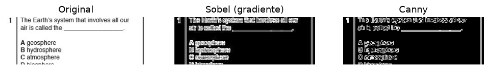

Sobel resalta la intensidad del borde; Canny devuelve contornos finos y binarios.

**En criollo:** si vas caminando y el piso pasa de claro a oscuro de golpe, ahí hay un "borde". El gradiente mide qué tan abrupto es ese escalón.

## Capítulo 5El dominio de la frecuencia (Fourier)

Toda imagen se puede pensar como una **suma de patrones ondulados** de distintas frecuencias. La **Transformada de Fourier** descompone la imagen en esas frecuencias:

- **Bajas frecuencias:** zonas suaves, grandes, el "fondo" general.
- **Altas frecuencias:** cambios rápidos → bordes, detalles finos, ruido.

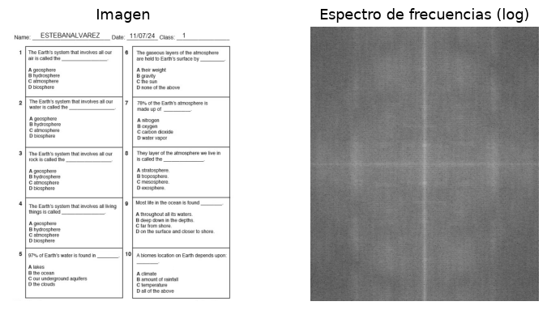

El espectro muestra qué frecuencias componen la imagen (el centro = bajas frecuencias).

¿Para qué sirve? Porque filtrar se vuelve muy fácil: si **borro las altas frecuencias** obtengo un suavizado (filtro pasa-bajo); si **borro las bajas**, me quedan los bordes (pasa-alto). Muchos filtros del capítulo 3 se pueden hacer también acá, a veces más rápido.

**Idea central:** el dominio espacial (píxeles) y el frecuencial (Fourier) son **dos formas de ver la misma imagen**. Se pasa de uno a otro con la FFT y su inversa.

## Capítulo 6Umbralado y binarización viste esto en el TP

**Binarizar** = convertir la imagen a solo dos valores (blanco/negro) según un **umbral**: si el píxel es más oscuro que el umbral → negro; si no → blanco. Es el primer paso para separar "objeto" de "fondo".

- **Umbral fijo:** elegís un número (ej. 127). Simple, pero sensible a la iluminación.
- **Otsu:** elige **automáticamente** el mejor umbral analizando el histograma.
- **Adaptativo:** usa un umbral distinto en cada zona (bueno con iluminación despareja).

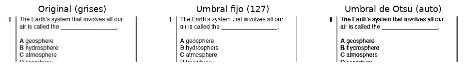

Umbral fijo vs. Otsu (que calcula el corte óptimo solo).

**En criollo:** en tu TP binarizaste el examen para poder **contar píxeles negros** por fila y columna, y así encontrar las líneas de la tabla. Todo eso arranca con un umbral.

## Capítulo 7Morfología matemática

Son operaciones sobre imágenes **binarias** que modifican las **formas**. Usan un "sello" chiquito llamado **elemento estructurante**.

- **Erosión:** **adelgaza** las figuras (come el borde). Elimina puntitos sueltos.
- **Dilatación:** **engrosa** las figuras (rellena huecos, une partes cercanas).
- **Apertura** (erosión→dilatación): limpia el ruido chico **sin** deformar lo grande.
- **Cierre** (dilatación→erosión): tapa agujeritos y une trazos cortados.

[figure not shown]

Erosión, dilatación y apertura sobre texto binarizado.

**Para probar:** `cv2.erode`, `cv2.dilate`, `cv2.morphologyEx(img, cv2.MORPH_OPEN, kernel)`. Cambiá el tamaño del elemento estructurante.

## Capítulo 8Segmentación y análisis de regiones el corazón del TP 2

**Segmentar** = dividir la imagen en regiones con significado (objetos, letras, celdas). Herramientas típicas:

- **Proyecciones:** sumar píxeles por fila y por columna. Los picos delatan líneas y estructuras. **Exactamente lo que usaste** para encontrar la grilla del examen.
- **Componentes conectadas:** agrupar píxeles vecinos que están "pegados" en objetos separados, con sus estadísticas (área, posición, tamaño). Lo usaste para aislar las respuestas y las líneas del encabezado.
- **Contornos:** obtener el borde de cada figura como una lista de puntos (`cv2.findContours`).

**Descriptor:** un resumen numérico de una región (área, perímetro, o —como en tu TP— el perfil de píxeles por fila). Sirve para **comparar** y **clasificar** formas, por ejemplo con distancia euclídea contra plantillas de referencia.

## Capítulo 9Detección de objetos y características viste caras en la Unidad 2

- **Transformada de Hough:** detecta formas geométricas (líneas, círculos) aunque estén incompletas.
- **Puntos de interés (keypoints):** esquinas y detalles distintivos que sirven para **alinear** o **reconocer** imágenes (SIFT, ORB).
- **Cascadas de Haar:** un detector clásico y rápido de objetos (caras) entrenado con muchos ejemplos. Es lo que corriste con `haarcascade_frontalface_alt.xml` para detectar y blurear caras.

**En criollo:** detectar un objeto es responder "¿está acá y dónde?". Las cascadas de Haar barren la imagen con una ventanita preguntando "¿esto parece una cara?" a distintas escalas.

## Capítulo 10Color y espacios de color

El mismo color se puede representar de varias formas ("espacios"):

- **RGB / BGR:** mezcla de rojo, verde y azul (OpenCV carga en **BGR**, ojo con eso).
- **Escala de grises:** un solo canal de brillo; simplifica muchísimo el procesamiento.
- **HSV:** Matiz (color), Saturación (intensidad del color) y Valor (brillo). Es **ideal para segmentar por color** (ej. "quedate con todo lo rojo"), porque separa el color del brillo.

**Para probar:** `cv2.cvtColor(img, cv2.COLOR_BGR2GRAY)` y `cv2.COLOR_BGR2HSV`. Muchos algoritmos trabajan mejor en grises o en HSV que en RGB.

## Capítulo 11Un vistazo a lo moderno (deep learning)

Todo lo anterior es procesamiento **"clásico"**: vos diseñás los filtros y las reglas. Hoy conviven con las **redes neuronales convolucionales (CNN)**, que **aprenden solas** los filtros a partir de miles de ejemplos.

La idea es la misma convolución del capítulo 3, pero apilada en muchas capas y con los kernels ajustados por entrenamiento. Se usan para clasificar, detectar (YOLO), segmentar y hasta generar imágenes.

**Cuándo cada uno:** lo clásico es predecible, liviano y no necesita datos (ideal para tareas acotadas como tu TP). El deep learning brilla en problemas complejos y variables, a costa de datos y cómputo.

## Capítulo 12Glosario y qué seguir

| Término | En una frase |
| --- | --- |
| Píxel | La celda mínima de la imagen; un número de brillo. |
| Histograma | Cuántos píxeles hay de cada nivel de gris. |
| Kernel / máscara | Matriz chica de pesos que define un filtro. |
| Convolución | Deslizar el kernel multiplicando y sumando por toda la imagen. |
| Pasa-bajos / pasa-altos | Suaviza (borronea) / resalta bordes y detalles. |
| Gradiente | Cuánto y hacia dónde cambia el brillo (bordes). |
| Umbral | Corte para separar objeto de fondo (binarizar). |
| Morfología | Operaciones que modifican formas binarias (erosión, dilatación…). |
| Componentes conectadas | Agrupar píxeles pegados en objetos separados. |
| Fourier / frecuencia | Ver la imagen como suma de ondas; filtrar por frecuencia. |

### Ruta sugerida para practicar

1. Cargá una foto en grises y mirá su histograma. Ecualizala.
2. Aplicá blur gaussiano y mediana; agregá ruido y compará.
3. Sacá bordes con Sobel y con Canny.
4. Binarizá con Otsu y probá erosión/dilatación/apertura.
5. Detectá contornos y contá objetos con componentes conectadas.

**Cierre:** casi todo el procesamiento de imágenes es combinar estos bloques: **transformar intensidades → filtrar → detectar bordes/umbralar → limpiar con morfología → segmentar y medir**. Tu TP recorrió esa cadena completa. 💪